# Protocol 5

Joachim Goedhart

2021-12-16

## Protocol 5 - A map of amino acids

This data visualization plots the position of amino acids in a given protein. It is inspired by figure 2A of the paper by [Basu et al. (2020)](https://www.sciencedirect.com/science/article/pii/S0092867420304815)

Let’s load the tidyverse package:

```r
library(tidyverse)
```

First, we define a vector with the 20 amino acids and the order in which we plot them. The amino acids are grouped as hydrophobic (G,A,V,C,P,I,L,M,F,W), hydrophilic (S,T,Y,N,Q), acidic (D,E) and basic (R,H,K).

```r
amino_acid_ordered <- strsplit("GAVCPILMFWSTYNQDERHK","") %>% unlist()
amino_acid_ordered
```

```
##  [1] "G" "A" "V" "C" "P" "I" "L" "M" "F" "W" "S" "T" "Y" "N" "Q" "D" "E" "R" "H" "K"
```

The protein sequence that we will use is the *Homo sapiens* Homeobox protein Hox-D13:

```r
protein <- c("MSRAGSWDMDGLRADGGGAGGAPASSSSSSVAAAAASGQCRGFLSAPVFAGTHSGRAAAA
AAAAAAAAAAASGFAYPGTSERTGSSSSSSSSAVVAARPEAPPAKECPAPTPAAAAAAPP
SAPALGYGYHFGNGYYSCRMSHGVGLQQNALKSSPHASLGGFPVEKYMDVSGLASSSVPA
NEVPARAKEVSFYQGYTSPYQHVPGYIDMVSTFGSGEPRHEAYISMEGYQSWTLANGWNS
QVYCTKDQPQGSHFWKSSFPGDVALNQPDMCVYRRGRKKRVPYTKLQLKELENEYAINKF
INKDKRRRISAATNLSERQVTIWFQNRRVKDKKIVSKLKDTVS")
```

The protein sequence may contain end-of-line characters “” after copy pasting and we need to remove these:

```r
protein <- gsub("\n", "", protein)
```

Next, the protein sequence is split into single characters and we assign this vector to `aa`:

```r
aa <- strsplit(protein, "") %>% unlist()
```

We generate a dataframe with a column with the amino acids and a column that defines their position:

```r
df_protein <- data.frame(aa=aa, position=1:length(aa))
```

Now we reorder the data frame to the order of the amino acids that we defined earlier in the vector `amino_acid_ordered`:

```r
df_protein <- df_protein %>% mutate(aa = fct_relevel(aa, amino_acid_ordered))
```

The basic plot shows a black tile for each amino acid. Note that the y-axis order is defined by the vector `amino_acid_ordered`, but it needs to be reverted to order the amino acids from top to bottom along the y-axis (which is naturally starts at the bottom it corresponds to the origin).

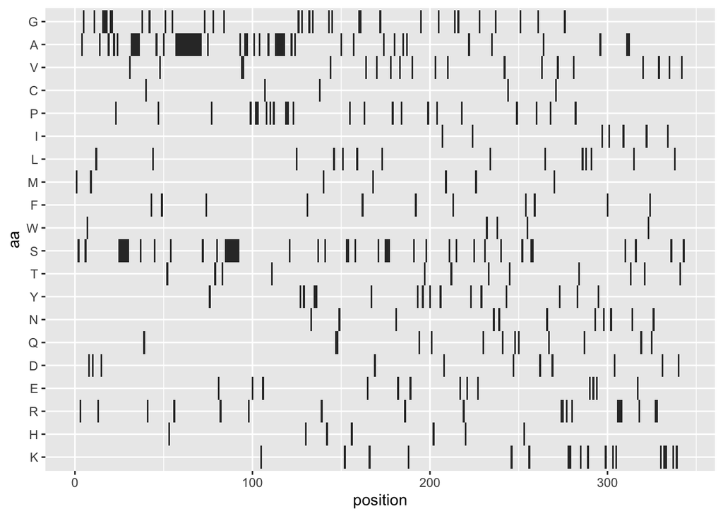

```r
p <- ggplot() + geom_tile(data=df_protein, aes(x=position, y=aa)) +
        scale_y_discrete(limits = rev(amino_acid_ordered))
p
```

Set the theme to classic, to get rid off the ‘frame’ around the plot and the grid.

```r
p <- p+theme_classic(base_size = 16)
```

For each of the four classes of amino acids we can define a box with a color that indicates the class. For example, there are three basic residues that will have a rectangle filled with blue in the background. The amino acids are factors, but we need numbers to define the coordinates for the rectangle. In a plot with a factors (here on the y-axis) their position is defined by a (non visible) natural number. Therefore we can define a box with the function `annotate()` for the first residue with y-coordinates `ymin=0.5` and `ymax=1.5`:

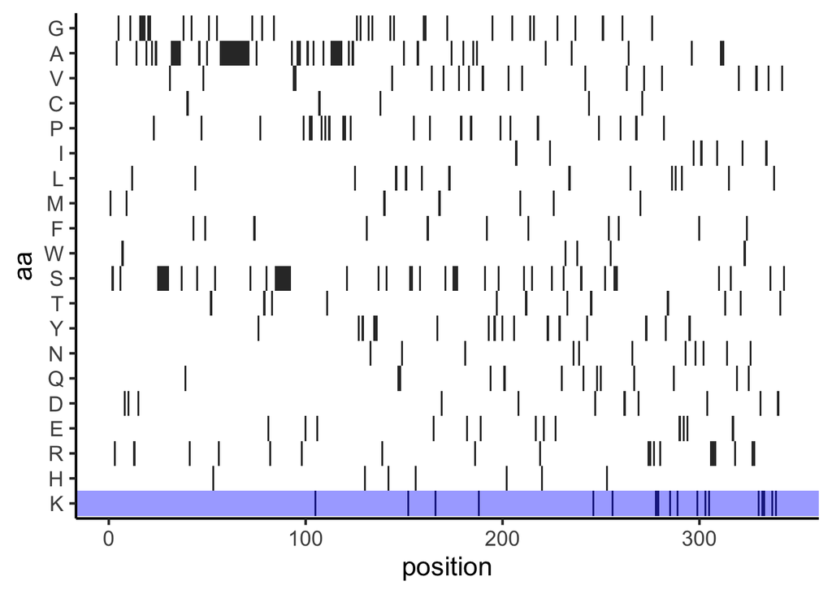

```r
p + annotate(geom = "rect", xmin = -Inf, ymin = 0.5, xmax = Inf, ymax=1.5, fill='blue', alpha=0.4)
```

In this way, we define four colored rectangles that reflect the different amino acids categories; blue=basic, red=acidic, yellow=hydrophilic, grey=hydrophobic:

```r
p <- p + annotate(geom = "rect", xmin = -Inf, ymin = 0.5, xmax = Inf, ymax=3.5, fill='blue', alpha=0.15)
p <- p + annotate(geom = "rect", xmin = -Inf, ymin = 3.5, xmax = Inf, ymax=5.5, fill='red', alpha=0.15)
p <- p + annotate(geom = "rect", xmin = -Inf, ymin = 5.5, xmax = Inf, ymax=10.5, fill='yellow', alpha=0.15)
p <- p + annotate(geom = "rect", xmin = -Inf, ymin = 10.5, xmax = Inf, ymax=20.5, fill='black', alpha=0.15)
```

Let’s look at the result:

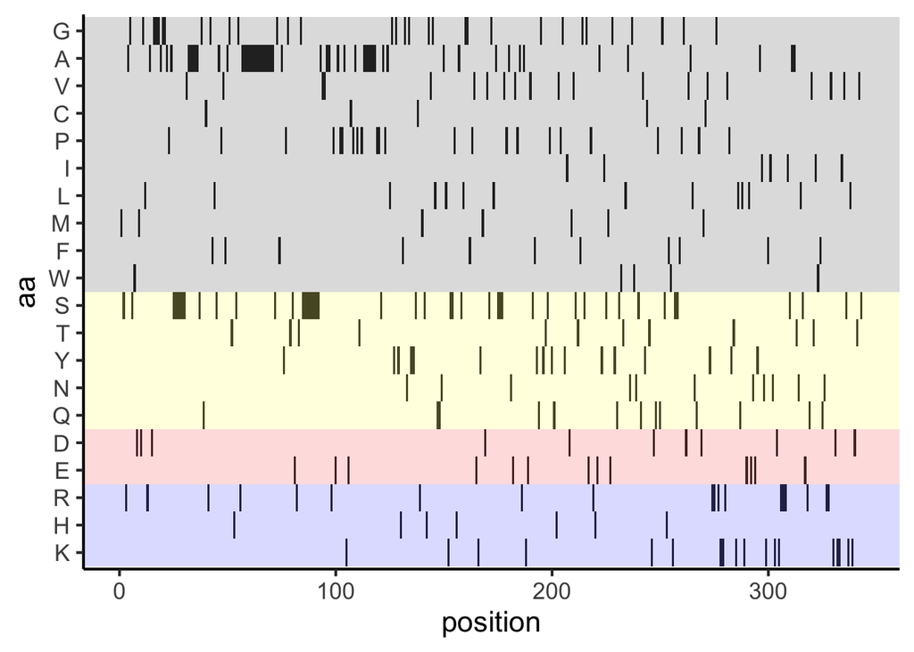

```r
p
```

Adjusting the axis labels and adding a title and caption:

```r
p <-
  p + labs(
    title = "Mapping the amino acid positions of HOXD13",
    subtitle = "shows a high abundance of alanines in the IDR",
    y = "Amino acid",
    caption = "(based on data from Basu et al, DOI: 10.1016/j.cell.2020.04.018)",
    tag = "Protocol 5"
  )
```

And a final tweak of the label style and location:

```r
p <- p + theme(
    plot.caption = element_text(
      color = "grey80",
      hjust = 1
    ))
```

In the original paper, a region of the protein is annotated as an ‘intrinsically disordered region’ abbreviated as IDR. Here, we we use the `annotate()` function to add a rectangle and a label to the top of the plot:

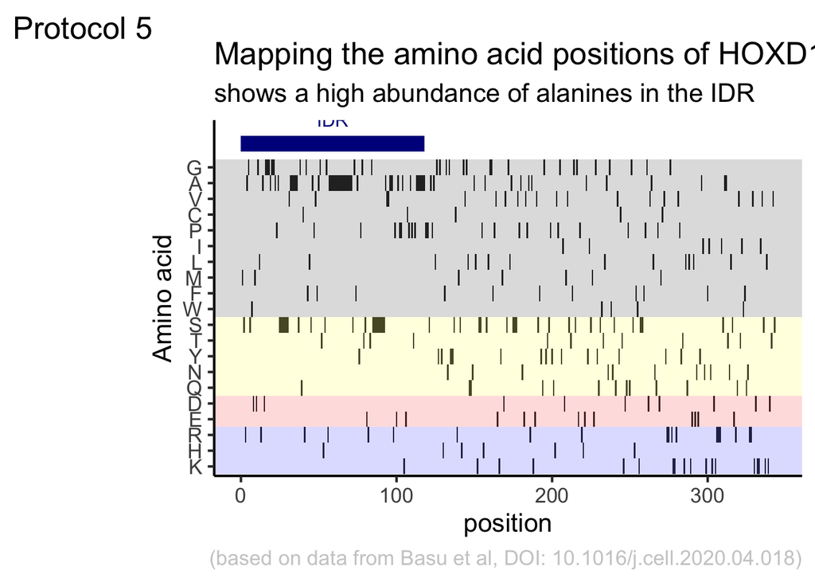

```r
p <- p + annotate("rect", xmin=0, xmax=118, ymin=21, ymax=22, fill='darkblue') +
  annotate("text", x=59, y=23, alpha=1, color='darkblue', size=4,label='IDR')
p
```

To avoid clipping of the new label by the subtitle of the plot:

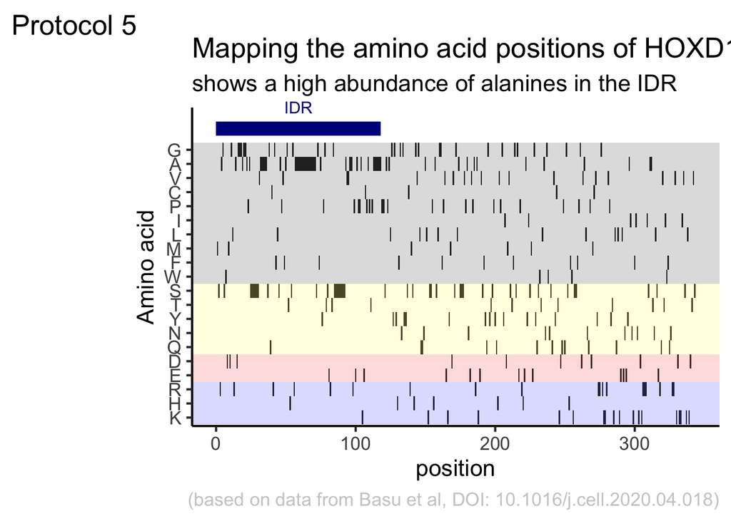

```r
p <- p + coord_cartesian(clip = 'off')
p
```

The subtitle is quite close to the IDR label. Let’s give the subtitle a bit more room, by adding a margin at the bottom of the subtitle. This can be done with the `theme()` function to style the subtitle:

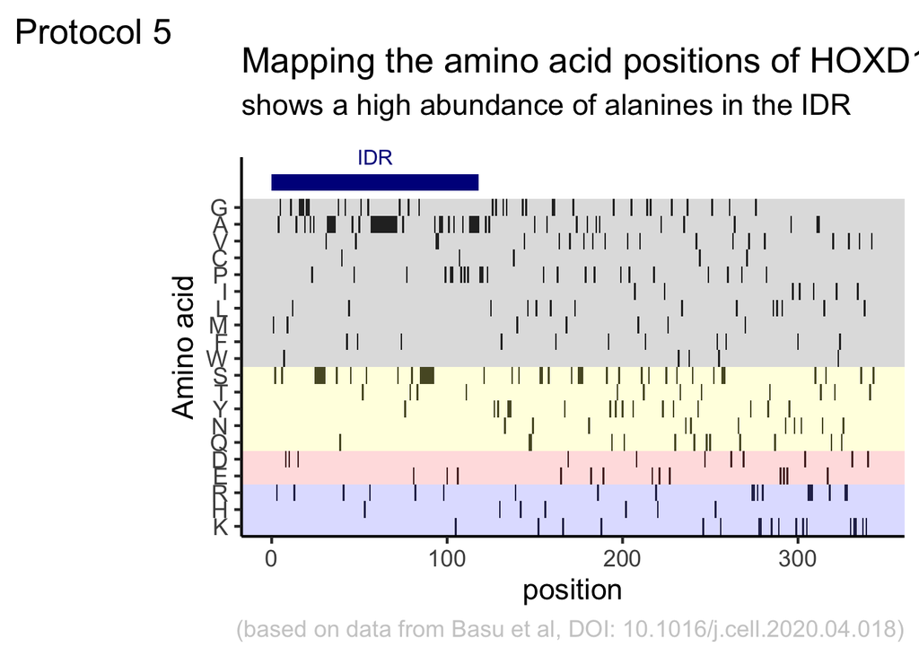

```r
p <- p + theme(plot.subtitle = element_text(margin = margin(b=20)))
p
```

Finally we can save the plot:

```r
png(file=paste0("Protocol_5.png"), width = 4000, height = 3200, units = "px", res = 400)
 p
dev.off()
```